# winequalityanalysis

```
                                          WINE QUALITY ANALYSIS
```

These Datasets can be viewed as classification or regression tasks . The classes are ordered and not balanced (e.g. there are munch more normal wines than excellent or poor ones) . Outlier detection algorithms could be used to detect the few excellent or poor wines. Also, we are not sure if all input variables are relevant. So it could be interesting to test feature selection methods .

we can know the basic defintions of some words that we are going to use in this project...

DATASET : Dataset is a collection of data pieces that can be treated by a computer as a single unit for analytic & prediction processes.

REGRESSION : Regression is used to predict the values (real or continuous values) , is a supervised Machine Learning Technique . "To plot a best-fit line or a curve between the data" is the ultimate goal of Regression Algorithm . Variance , Bias , Error are the three metrics thet are used for evaluating the Trained Regression Model .

DETECTION : Detection is a crucial process in Machine Learning that helps to identify the unusual patterns in Datasets .

DATA VISUALIZATION : It is the process of finding , interpreting and comparing the data so that it can communicate more clearly complex ideas , thus making it easier to identify once analysis of logical patterns .

what is statistic ?

Statistics is an area of applied mathematics concerned with the data collection , analysis , interpretation & presentaton .

Statistical Measures are the measures where we can see how data can be used to solve complex problems .

Here , first we are going to import the libraries like "pandas,numpy,matplotlib" in which : 1. pandas - used for data analysis & manipulation . 2. numpy - used for scientific computations , contains multi-dimensional array & matrix data structure . 3. matplotlib - used for data visualization . 4.seaborn - used for data visualization .

Importing the Libraries

```python
import pandas as pd
import numpy as np
import matplotlib.pyplot as plt
import seaborn as sns
```

Data Collection

```python
#loading the Dataset to a pandas DataFrame
wines=pd.read_excel(r"C:\Users\vaddi\OneDrive\Desktop\Major Project Dataset (Wine Classification).xlsx")
```

Here we used some functions which are used to get information about the Dataset :

head() : The head() function returns specified number of rows , string from the top . The head() function returns the first 5 rows if a number is not specified .

NOTE : The column names will also be returned , in addition to the specified rows .

info() : The info() function gives the information about the DataFrame . The information contains the number of columns , column data types , column labels , memory usuage, the number of cells in each column (non-null values) and the range index .

shape : The shape function is used to determine the dimensions of arrays & dataframes . This information is provided in the form of tuple . In python , the shape function is applied to objects likes numpy , array or pandas dataframes .

```python
# gives first 5 rows of Dataset
wines.head()
```

|  | fixed acidity | volatile acidity | citric acid | residual sugar | chlorides | free sulfur dioxide | total sulfur dioxide | density | pH | sulphates | alcohol | quality |
| --- | --- | --- | --- | --- | --- | --- | --- | --- | --- | --- | --- | --- |
| 0 | 7.4 | 0.70 | 0.00 | 1.9 | 0.076 | 11.0 | 34.0 | 0.9978 | 3.51 | 0.56 | 9.4 | 5.0 |
| 1 | 7.8 | 0.88 | 0.00 | 2.6 | 0.098 | 25.0 | 67.0 | 0.9968 | 3.20 | 0.68 | 9.8 | 5.0 |
| 2 | 7.8 | 0.76 | 0.04 | 2.3 | 0.092 | 15.0 | 54.0 | 0.9970 | 3.26 | 0.65 | 9.8 | 5.0 |
| 3 | 11.2 | 0.28 | 0.56 | 1.9 | 0.075 | 17.0 | 60.0 | 0.9980 | 3.16 | 0.58 | 9.8 | 6.0 |
| 4 | 7.4 | 0.70 | 0.00 | 1.9 | 0.076 | 11.0 | 34.0 | 0.9978 | 3.51 | 0.56 | 9.4 | 5.0 |

```python
wines.info()
```

```
<class 'pandas.core.frame.DataFrame'>
RangeIndex: 1599 entries, 0 to 1598
Data columns (total 12 columns):
 #   Column                Non-Null Count  Dtype
---  ------                --------------  -----
 0   fixed acidity         1599 non-null   float64
 1   volatile acidity      1599 non-null   float64
 2   citric acid           1599 non-null   float64
 3   residual sugar        1599 non-null   float64
 4   chlorides             1599 non-null   float64
 5   free sulfur dioxide   1599 non-null   float64
 6   total sulfur dioxide  1598 non-null   float64
 7   density               1599 non-null   float64
 8   pH                    1598 non-null   float64
 9   sulphates             1599 non-null   float64
 10  alcohol               1599 non-null   float64
 11  quality               1598 non-null   float64
dtypes: float64(12)
memory usage: 150.0 KB
```

```python
# number of rows and columns in the Dataset
wines.shape
```

```
(1599, 12)
```

Detecting the missing values

Inorder to check missing values we use two functions :

isnull() : isnull() is used to identify or detect the missing values in the dataframe . It is same as isna() function , it also returns a dataframe of the same size where the values such as Nope or Np . NaN is is taken as True & other values are taken as False .

sum() : The sum() function returns a number , the sum of all items in an iterable .

```python
#checking for missing values
wines.isnull().sum()
```

```
fixed acidity           0
volatile acidity        0
citric acid             0
residual sugar          0
chlorides               0
free sulfur dioxide     0
total sulfur dioxide    1
density                 0
pH                      1
sulphates               0
alcohol                 0
quality                 1
dtype: int64
```

```python
#imputing the missing values by means as the data present in the different columns are continuous values
for col in wines.columns:
    if wines[col].isnull().sum()>0:
        wines[col]=wines[col].fillna(wines[col].mean())
wines.isnull().sum().sum()
```

```
0
```

```python
wines.isnull().sum()
```

```
fixed acidity           0
volatile acidity        0
citric acid             0
residual sugar          0
chlorides               0
free sulfur dioxide     0
total sulfur dioxide    0
density                 0
pH                      0
sulphates               0
alcohol                 0
quality                 0
dtype: int64
```

Data Analysis and Visualization

```python
#stastical measures of the Dataset
wines.describe()
```

|  | fixed acidity | volatile acidity | citric acid | residual sugar | chlorides | free sulfur dioxide | total sulfur dioxide | density | pH | sulphates | alcohol | quality |
| --- | --- | --- | --- | --- | --- | --- | --- | --- | --- | --- | --- | --- |
| count | 1599.000000 | 1599.000000 | 1599.000000 | 1599.000000 | 1599.000000 | 1599.000000 | 1599.000000 | 1599.000000 | 1599.000000 | 1599.000000 | 1599.000000 | 1599.000000 |
| mean | 8.319637 | 0.527821 | 0.270976 | 2.538806 | 0.087467 | 15.874922 | 46.433041 | 0.996747 | 3.498586 | 0.658149 | 10.422983 | 5.636421 |
| std | 1.741096 | 0.179060 | 0.194801 | 1.409928 | 0.047065 | 10.460157 | 32.865961 | 0.001887 | 0.080321 | 0.169507 | 1.065668 | 0.807413 |
| min | 4.600000 | 0.120000 | 0.000000 | 0.900000 | 0.012000 | 1.000000 | 6.000000 | 0.990070 | 2.740000 | 0.330000 | 8.400000 | 3.000000 |
| 25% | 7.100000 | 0.390000 | 0.090000 | 1.900000 | 0.070000 | 7.000000 | 22.000000 | 0.995600 | 3.520000 | 0.550000 | 9.500000 | 5.000000 |
| 50% | 7.900000 | 0.520000 | 0.260000 | 2.200000 | 0.079000 | 14.000000 | 38.000000 | 0.996750 | 3.520000 | 0.620000 | 10.200000 | 6.000000 |
| 75% | 9.200000 | 0.640000 | 0.420000 | 2.600000 | 0.090000 | 21.000000 | 62.000000 | 0.997835 | 3.520000 | 0.730000 | 11.100000 | 6.000000 |
| max | 15.900000 | 1.580000 | 1.000000 | 15.500000 | 0.611000 | 72.000000 | 289.000000 | 1.003690 | 3.900000 | 2.000000 | 14.900000 | 8.000000 |

Based on this Dataset , Let's know about plots by comparing one column with other column which are in the Dataset .

Firstly , we are going to know that how many types of plots are there ...

Plot : The simplest way to create a plot is using the module , which provides a MATLAB - like interface for charts creating .

There are so many types of plots but here we used some of them to represent the plots related to this Dataset .

1 . catplot : catplot is the function in the Seaborn library i.e., used to create categorical plots . Categorical plots are the plots which are used to visualize the relationship between two or more categorical variables . ( Categorical variable is a variable has values that you can put into a countable number of distinct groups based on a characteristics . Categorical variable is also called Qualitative variables . )

2 . barplot : barplot is a plot which is used to visualize the data as bar charts .

3 . histogram : we can create a histogram to see or visualize hoe the data is distributed .

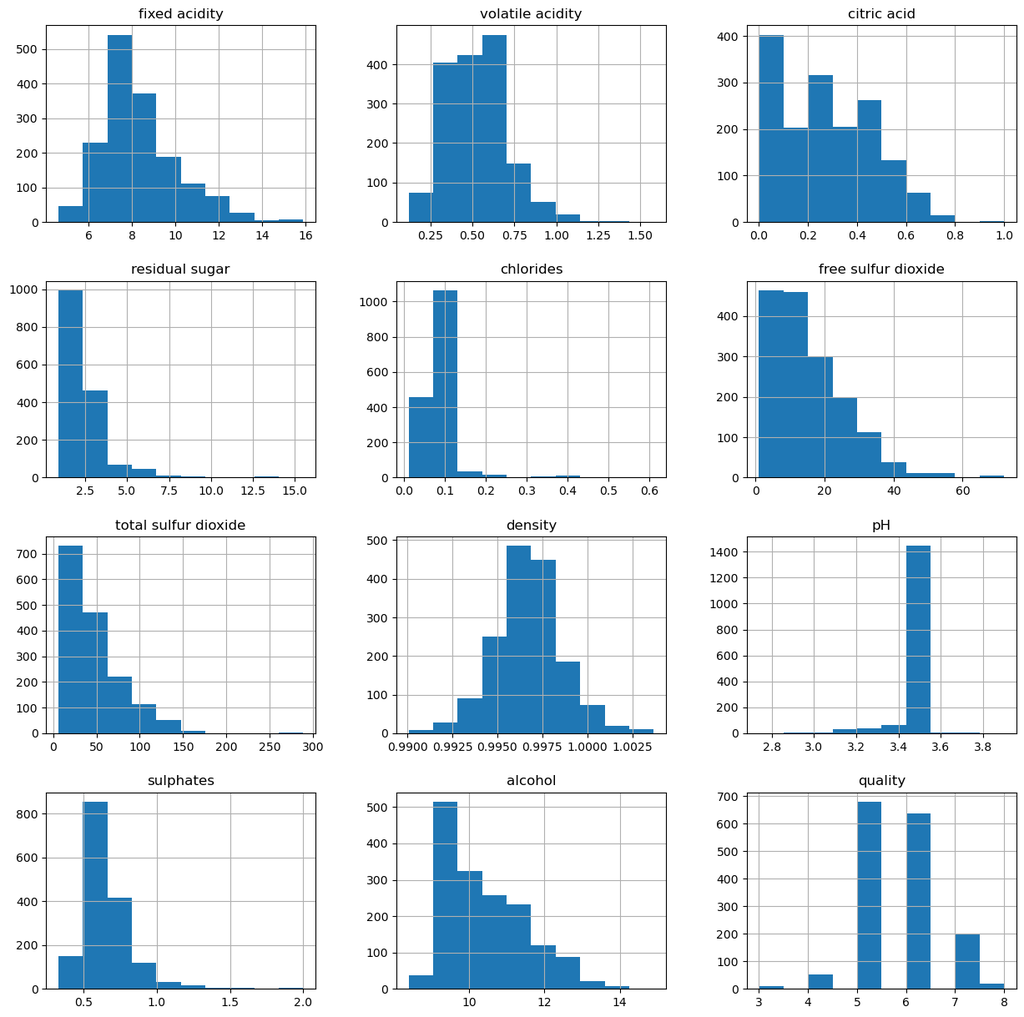

```python
#drawing histogram to visualize the distribution of the data with continuous values of columns in the Dataset
wines.hist(bins=10,figsize=(15,15))
plt.show()
```

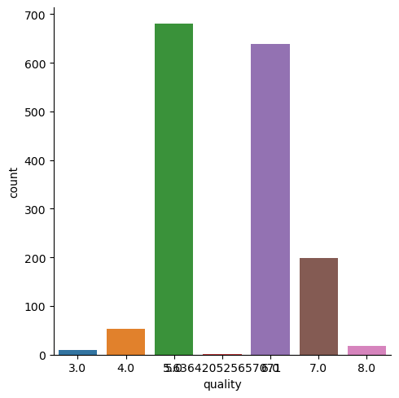

```python
#drawing count plot to visualize the number data for each quality of wine
sns.catplot(x='quality',data=wines,kind='count')
```

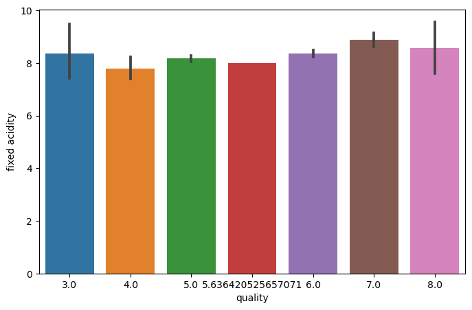

```python
#fixed acidity vs quality
plot=plt.figure(figsize=(8,5))
sns.barplot(x='quality',y='fixed acidity',data=wines)
```

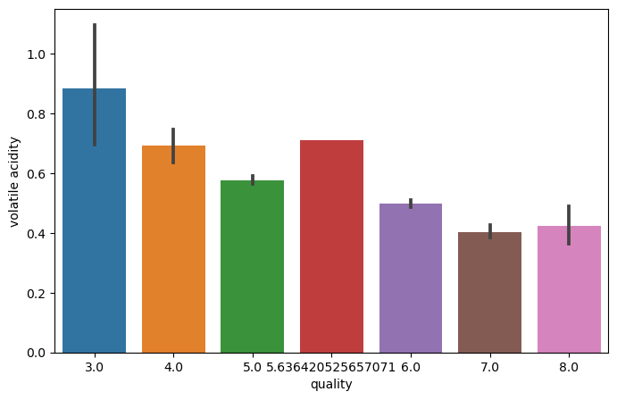

```python
#volatile acidity vs quality
plot=plt.figure(figsize=(8,5))
sns.barplot(x='quality',y='volatile acidity',data=wines)
```

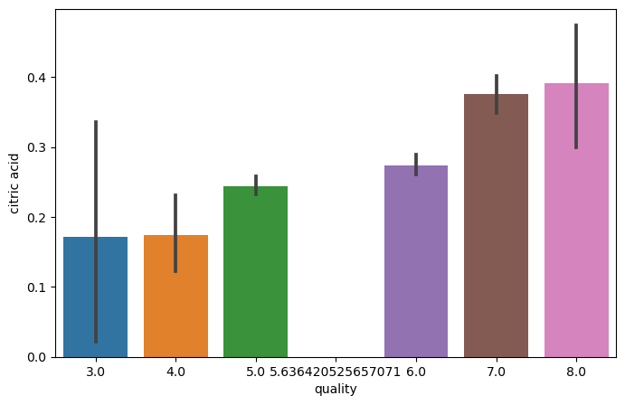

```python
#citric acid vs quality
plot=plt.figure(figsize=(8,5))
sns.barplot(x='quality',y='citric acid',data=wines)
```

Correlation

Correlation is a Statistical analysis taht measures the strength and direction of the relationship between two or more variables .

Correlation is of two types : 1 . Positive Correlation , 2 . Negative Correlation

Now we can know what is positive and negative coorelations .

1 . Positive Correlation : In Machine Learning , when two variables move in the same direction , meaning that as one variable increases so that the other value is at constant .Then we say it as Positive Correlation .

2 . Negative Correlation : It is the relationship between the two variables that move in opposite directions , when one variable increases so that the other decreases and vice versa .

Here , we are going to draw a heatmap related to our Dataset.

Heatmap : A Two-Dimensional representation of data in which various values are represented by colors is known as heatmap . Heatmap allows user to quickly grasp relevant & important data points . It consists of paramaters correlation , cbar(colorbar),square(if True it gives squares or else not) , fmt(format) , annot(if True the value is annotated in heatmap or else not) , annot_kws(is used to change the text properties here we changed the text size) , cmap(color of the map) .

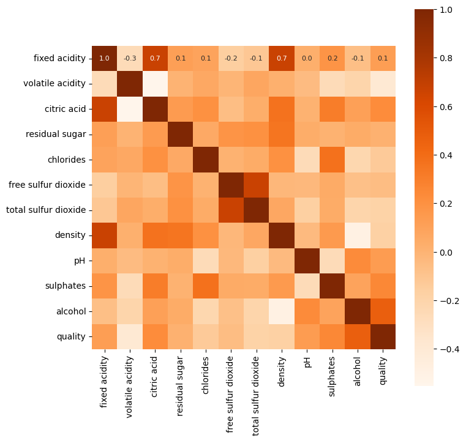

```python
#to understand the correlation between the coloumns we are constructing a heatmap
correlation=wines.corr()
plt.figure(figsize=(8,8))
sns.heatmap(correlation,cbar=True,square=True,fmt='.1f',annot=True,annot_kws={'size':8},cmap='Oranges')
```

Data Preprocessing

Data Preprocessing is the process of evaluating , filtering , manipulating , and encoding data so that a Machine Learning Algorithm can understand it and use the resulting output . The main goal of Data Preprocessing is to eliminate data issues such as missing values , improve data quality , and make the data useful for Machine Learning purposes .

```python
#separating the data and label
X=wines.drop('quality',axis=1)
print(X)
```

```
      fixed acidity  volatile acidity  citric acid  residual sugar  chlorides  \
0               7.4             0.700         0.00             1.9      0.076
1               7.8             0.880         0.00             2.6      0.098
2               7.8             0.760         0.04             2.3      0.092
3              11.2             0.280         0.56             1.9      0.075
4               7.4             0.700         0.00             1.9      0.076
...             ...               ...          ...             ...        ...
1594            6.2             0.600         0.08             2.0      0.090
1595            5.9             0.550         0.10             2.2      0.062
1596            6.3             0.510         0.13             2.3      0.076
1597            5.9             0.645         0.12             2.0      0.075
1598            6.0             0.310         0.47             3.6      0.067

      free sulfur dioxide  total sulfur dioxide  density    pH  sulphates  \
0                    11.0                  34.0  0.99780  3.51       0.56
```

[output cut: 25 more lines]

Label Binarization

Here , we are converting the categorical values into the binary values i.e., 0 & 1 is said to be as Linear Binarization .

```python
Y=wines['quality'].apply(lambda y_value: 1 if y_value>=7 else 0)
print(Y)
```

```
0       0
1       0
2       0
3       0
4       0
       ..
1594    0
1595    0
1596    0
1597    0
1598    0
Name: quality, Length: 1599, dtype: int64
```

Train_Test_Split Method

train_test_split method is a technique that divides a Dataset into two subsets one is a training set & a test set . And is generally used in Supervised Machine Learning for Regression & Classification of model .

1 . Train set : Training set is used to train the model .

2 . Test set : The Test set is used to evaluate the model's performance .

While we are training and testing the sets it contains the text_size ( describes the number that defines the size of the test set i.e., here we taken as 25%(0.25)) and random_state ( is a parameter that controls the random number generator used to shuffle the data before splitting it ) within the paranthesis .

```python
from sklearn.model_selection import train_test_split
```

```python
X_train,X_test,Y_train,Y_test=train_test_split(X,Y,test_size=0.25,random_state=3)
print(Y.shape)
print(Y_train.shape)
print(Y_test.shape)
```

```
(1599,)
(1199,)
(400,)
```

Model Training :

Random Forest Classifier

A Random Forest Classifier is a Machine Learning Algorithm that combines the output of multiple decision trees to reach a single result .

```python
from sklearn.ensemble import RandomForestClassifier
```

```python
model=RandomForestClassifier()
model.fit(X_train,Y_train)
```

```
RandomForestClassifier()
```

Model Evaluation

Accuracy Score

Accuracy is a metric that measures how often a Machine Learning Model correctly predicts the output . We can calculate accuracy as :

Accuracy = Number of Correct Predictions divided by Total Number of Predictions .

```python
from sklearn.metrics import accuracy_score
```

```python
#accuracy on test data
X_test_prediction=model.predict(X_test)
test_wines_accuracy=accuracy_score(X_test_prediction,Y_test)
print('Accuracy :',test_wines_accuracy)
```

```
Accuracy : 0.94
```

Here we are converting the input data into numpy array because numpy arrays are a powerful tool for Machine Learning . By converting our data into numpy arrays , we can improve the memory efficiency , speed , and capability of our code .

And also we are reshaping the data that helps the input data more useful and managable . It makes the data easy to accessible , analyse and more informative as by reshaping we can convert or transform data from one format to another format .

Building a Predictive System

```python
given_data=(7.8,0.58,0.02,2,0.073,9,18,0.9968,3.36,0.57,9.5)

#converting the given data into a numpy array
numpy_array=np.asarray(given_data)

#as we are predicting the label for only one instance so we're reshaping the data
reshaped_data=numpy_array.reshape(1,-1)

prediction=model.predict(reshaped_data)
print(prediction)

if (prediction[0]==1):
    print('Wine Quality is Good...')
else:
    print('Wine Quality is Not Good...')
```

```
[1]
Wine Quality is Good...
```